# xwMOOC 자동차

공공데이터포털 - 대한민국 리콜(2011-2016)

xwMOOC

2017-12-29

## 1. 자동차 리콜 [^1]

공공데이터포털에서 [자동차결함 리콜현황](https://www.data.go.kr/dataset/3048950/fileData.do) 데이터를 받아볼 수 있다. 2017년은 현재시점(2017-12-29) 올라와있지 않지만, 2011-2016년까지는 다양한 형태로 데이터를 정제하지도 않은 상태로 `.csv`, `.xls` 파일 형태로 올라와 있다.

따라서, 추가적인 분석을 위해서 데이터정제 작업은 각자 진행하여 분석작업을 수행한다.

## 2. 연도별 품질 문제가 많은 자동차 제조사

### 2.1. 데이터 가져오기

2011년부터 2016년까지 데이터를 불러온다. UTF-8인코딩을 맞추기 위해서 `read.csv` 함수로 `fileEncoding="EUC-KR"` 인자를 넘겨 우선 데이터를 불러들인다.

```r
# 0. 환경설정 ---------------
# library(tidyverse)
# library(readxl)
# library(xts)
# library(stringr)
# library(lubridate)
# library(ggpubr)
# library(extrafont)
# loadfonts()

# 1. 데이터 가져오기 ------

recall_2011_dat <- read.csv("data/공공데이터포털/리콜현황(2011년).csv", fileEncoding="EUC-KR", skip=1)
recall_2012_dat <- read.csv("data/공공데이터포털/리콜현황(2012년).csv", fileEncoding="EUC-KR", skip=1)
recall_2013_dat <- read.csv("data/공공데이터포털/자동차 결함 리콜현황(2013년).csv", fileEncoding="EUC-KR")
recall_2014_dat <- read_excel("data/공공데이터포털/리콜현황(2014년).xlsx", skip=1)
recall_2015_dat <- read.csv("data/공공데이터포털/자동차리콜현황(2015).csv", fileEncoding="EUC-KR")
recall_2016_dat <- read.csv("data/공공데이터포털/자동차리콜현황(2016).csv", fileEncoding="EUC-KR")
```

### 2.2. 데이터 전처리

데이터 형태가 다르기 때문에 해당 연도에 맞춰 적절한 형태로 연도별 데이터프레임을 적절한 형태로 가공한다.

```r
# 2. 데이터 전처리 ------
## 2011년
recall_2011_df <- recall_2011_dat %>%
  tbl_df() %>%
  mutate(연도 = "2011-01-01") %>%
  separate(생산기간, into=c("생산시작", "생산종료"), sep="~")

## 2012년
recall_2012_df <- recall_2012_dat %>%
  tbl_df() %>%
  mutate(연도 = "2012-01-01") %>%
  separate(생산기간, into=c("생산시작", "생산종료"), sep="~")

## 2013년
recall_2013_df <- recall_2013_dat %>%
  tbl_df() %>%
  mutate(연도 = "2013-01-01") %>%
  rename(생산시작=`생산기간.부터.`, 생산종료=`생산기간.까지.`)

## 2014년
recall_2014_df <- recall_2014_dat %>%
  tbl_df() %>%
  mutate(연도 = "2014-01-01") %>%
  separate(생산기간, into=c("생산시작", "생산종료"), sep="~")

## 2015년
recall_2015_df <- recall_2015_dat %>%
  tbl_df() %>%
  mutate(연도 = "2015-01-01") %>%
  rename(생산시작=`생산기간.부터.`, 생산종료=`생산기간.까지.`)

## 2016년
recall_2016_df <- recall_2016_dat %>%
  tbl_df() %>%
  mutate(연도 = "2016-01-01") %>%
  rename(생산시작=`생산기간.부터.`, 생산종료=`생산기간.까지.`) %>%
  select(-X, -X.1)

## 데이터 병합 -----------
recall_df <- recall_2011_df %>%
  bind_rows(recall_2012_df) %>%
  bind_rows(recall_2013_df) %>%
  bind_rows(recall_2014_df) %>%
  bind_rows(recall_2015_df) %>%
  bind_rows(recall_2016_df)
```

### 2.3. 데이터 전처리 - 제조사

자동차 제조사를 적절한 범주로 나눠 다시 재분류한다.

```r
# 2. 데이터 전처리 ------
## 2.1. 자동차 제조사 정리 -----
recall_df <- recall_df %>%
  mutate(제조사 = case_when(
    str_detect(제작사, "대우|지엠|GM|타타") ~ "지엠대우",
    str_detect(제작사, "현대") ~ "현대차",
    str_detect(제작사, "기아") ~ "기아차",
    str_detect(제작사, "혼다") ~ "혼다",
    str_detect(제작사, "볼보") ~ "볼보",
    str_detect(제작사, "토요타") ~ "토요타",
    str_detect(제작사, "벤츠|다임러") ~ "다임러벤츠",
    str_detect(제작사, "닛산") ~ "닛산",
    str_detect(제작사, "에프씨에이|크라이슬러") ~ "크라이슬러",
    str_detect(제작사, "비엠더블유") ~ "BMW",
    str_detect(제작사, "아우디") ~ "아우디",
    str_detect(제작사, "포드") ~ "포드",
    str_detect(제작사, "재규어|랜드로버") ~ "재규어랜드로버",
    str_detect(제작사, "한불") ~ "푸조",
    str_detect(제작사, "기흥") ~ "애스턴마틴",
    str_detect(제작사, "스즈키") ~ "스즈키",
    str_detect(제작사, "삼성") ~ "르노삼성",
    str_detect(제작사, "쌍용") ~ "쌍용",
    str_detect(제작사, "포르쉐|스투트가르트") ~ "포르쉐",
    str_detect(제작사, "만트럭|만 트럭") ~ "만트럭",
    str_detect(제작사, "스카니아") ~ "스카니아",
    str_detect(제작사, "모토로싸|모터로싸") ~ "두카티",
    str_detect(제작사, "스바루") ~ "스바루",
    str_detect(제작사, "에프엠케이") ~ "마세라티-페라리",
    str_detect(제작사, "미쓰비시") ~ "미쓰비시",
    str_detect(제작사, "대전") ~ "오토바이-대전",
    str_detect(제작사, "한국모터") ~ "오토바이-야마하",
    str_detect(제작사, "스포츠모터사이클") ~ "오토바이-TKM",
    str_detect(제작사, "S&T모터스|대림|화창") ~ "오토바이-스즈키",
    str_detect(제작사, "모토스타코리아") ~ "오토바이-SYM",
    str_detect(제작사, "락락") ~ "스타크래프트밴",
    str_detect(제작사, "씨엔에이치") ~ "이베코-버스",
    TRUE ~ "기타"
  ))
# 오토바이 제외 !!!
recall_df <- recall_df %>%
  filter(!str_detect(제조사, "오토바이"))
```

### 2.4. 데이터 전처리 - 리콜일

리콜시작일이 연도마다 다르기 때문에 적절한 형태로 가공한다.

```r
## 2.2. 리콜개시일 -----
recall_df <- recall_df %>%
  mutate(리콜개시일 = str_replace_all(리콜개시일, "\\`", "")) %>%
  mutate(리콜시작일 = str_split(리콜개시일,"\\.|-|~")) %>%
  mutate(연도 = map_chr(리콜시작일, 1),
         월 = map_chr(리콜시작일, 2),
         일 = map_chr(리콜시작일, 3)) %>%
  mutate(월 = str_pad(월, 2, "left", pad="0"),
         일 = str_pad(일, 2, "left", pad="0"),
         연도 = ifelse(str_length(연도) ==2, paste0("20", 연도), 연도)) %>%
  mutate(리콜일 = lubridate::ymd(paste0(연도, "-", 월, "-", 일))) %>%
  select(-연도, -월, -일, -리콜시작일, -리콜개시일)
```

## 3. 나름 정리한 데이터

제조사, 리콜일을 정리한 데이터를 향후 분석을 위해 살펴보자. 추가적인 분석을 원하는 경우 클릭하여 다운로드하여 가져간다.

```r
# 4. 리콜 데이터 표 -----
recall_df %>%
  select(리콜일, 제조사, 제작사, 차명, 생산시작, 생산종료, 리콜사유) %>%
  DT::datatable()
```

|  | 리콜일 | 제조사 | 제작사 | 차명 | 생산시작 | 생산종료 | 리콜사유 |
| --- | --- | --- | --- | --- | --- | --- | --- |
| 1 | 2011-03-23 | 현대차 | 현대자동차㈜ | 아반떼하이브리드 | `09.12.01 | `10.03.31 | 후부반사기의 반사성능이 안전기준에 부적합한 결함이 발견됨 |
| 2 | 2011-04-27 | 현대차 | 현대자동차㈜ | 투싼YF쏘나타 | `10.2.27 | `10.5.17 | 후부반사기의 반사성능이 안전기준에 부적합한 결함이 발견됨 |
| 3 | 2011-08-16 | 기아차 | 기아자동차㈜ | 모닝 | `11.4.19 | `11.7.29 | 휘발유 연료탱크 내 유량계가 연료탱크에 접촉되어 정상적으로 작동되지 않을 수 있고 이 경우 연료가 부족함에도 있는 것처럼 표시되어 운전자가 연료가 있는 것으로 알고 운전할 경우 시동꺼짐 현상이 발생할 수 있어 안전운행에 지장 |
| 4 | 2011-03-08 | 르노삼성 | 르노삼성자동차㈜ | SM3 | `10.4.16 | `10.4.19 | 실내좌석 내장재의 난연성이 안전기준에 부적합한 결함 발견됨 |
| 5 | 2011-04-29 | 르노삼성 | 르노삼성자동차㈜ | SM3 | `10.4.1 | `11.1.16 | 후부반사기의 반사성능이 안전기준에 부적합한 결함이 발견됨 |
| 6 | 2011-04-29 | 르노삼성 | 르노삼성자동차㈜ | SM3SM5 | `09.4.23 | `10.10.29 | 에어백 제어장치 불량으로 운전석 에어백이 작동되지 않을 가능성이 발견됨 |
| 7 | 2011-12-26 | 르노삼성 | 르노삼성자동차㈜ | QM5 | `10.9.13 | `11.1.19 | 주행 중 파워스티어링 제어장치 결함으로 핸들이 무거워져 안전운행에 지장 |
| 8 | 2011-10-21 | 지엠대우 | 한국지엠㈜ | 윈스톰2.0디젤윈스톰맥스2.0디젤토스카2.0디젤라세티2.0디젤라세티프리미어2.0디젤 | `08.2.1 | `11.6.20 | 경유를 사용하는 자동차의 연료공급호스 불량으로 연료가 누유 될 수 있고, 이 경우 주행 중 시동이 꺼져 안전운행에 지장 |
| 9 | 2011-12-02 | 지엠대우 | 한국지엠㈜ | 쉐보레캡티바 | `11.8.26 | `11.9.15 | 연료탱크와 연료주입구 연결부위가 분리될 수 있고 이 경우 연료가 누유되어 안전운행에 지장 |
| 10 | 2011-02-09 | 토요타 | 한국토요타자동차㈜ | 렉서스 IS250 | `07.9.3 | `08.12.3 | 연료파이프에 연결된 연료압력센서가 기준보다 낮은 힘으로 체결되어 연료가 누유 될 가능성이 있어 안전운행에 지장 |

[output cut: 1643 more lines]

## 4. 현대차, 기아차를 포함한 리콜 상위 10사

현대, 기아차는 리콜 상위 10위안에 들지 못했지만, 2011년부터 리콜 명령을 받은 횟수가 높은 제조사를 연도별로 시각화하자.

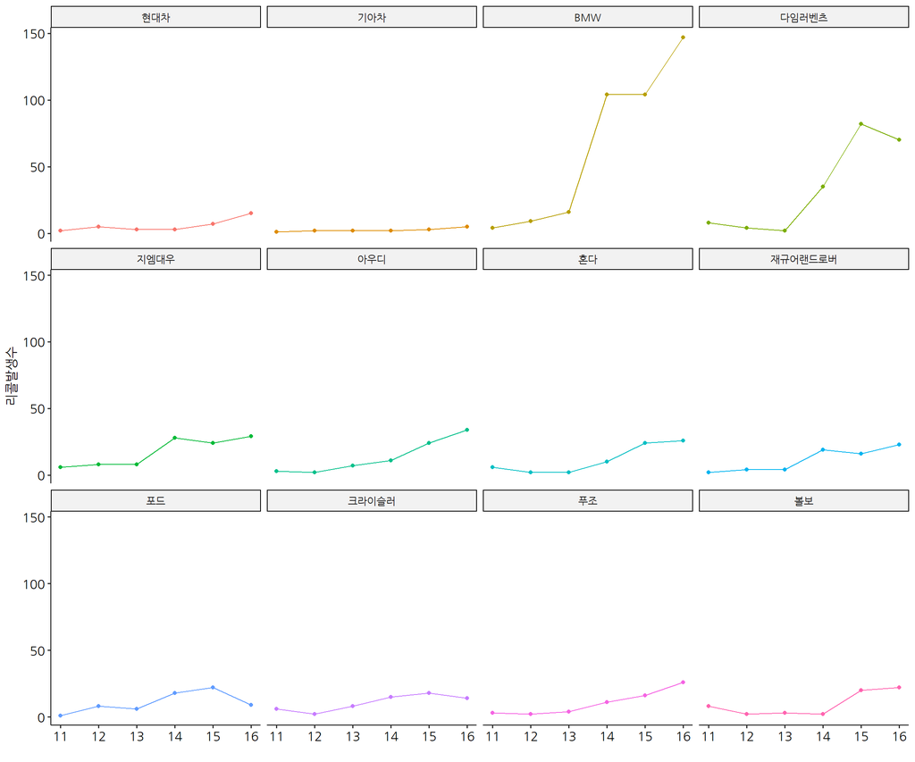

```r
# 3. 연도별 리콜 시각화 -----

top_10_maker_v <- recall_df %>%
  mutate(리콜년도 = year(리콜일)) %>%
  count(제조사, sort=TRUE) %>%
  top_n(10, n) %>% pull(제조사) %>%
  c("현대차", "기아차")

recall_df %>%
  mutate(리콜년도 = year(리콜일)-2000) %>%
  count(리콜년도, 제조사, sort=TRUE) %>%
  filter(제조사 %in% top_10_maker_v) %>%
  mutate(제조사 = factor(제조사, levels=c("현대차", "기아차", "BMW", "다임러벤츠", "지엠대우", "아우디", "혼다", "재규어랜드로버",
                                    "포드", "크라이슬러", "푸조", "볼보"))) %>%
  ggplot(aes(x=리콜년도, y=n, group=제조사, color=제조사)) +
    geom_point() +
    geom_line() +
    facet_wrap(~제조사) +
    theme_pubr(base_family = "NanumGothic") +
    labs(x="", y="리콜발생수") +
    theme(legend.position = "none")
```

[^1]: [카미디어, 올해 車리콜 역대 최대..현대-기아차 80% 차지, 2017.12.29 10:16](http://v.auto.daum.net/v/L5uIFeCQLn)